# Notebook

## Chapter 3 Confidence intervals

Point estimation (population vs sample)

In statistical inference, we want to learn **population parameters** using **sample data**.

- **Population parameter**: a fixed (unknown) quantity, e.g. population mean $\mu$, population proportion $p$, population standard deviation $\sigma$.
- **Statistic**: a quantity computed from a sample, e.g. sample mean $\bar{x}$, sample proportion $\hat{p}$, sample standard deviation $s$.

A **point estimate** is a single statistic used as the “best guess” of a parameter. Common point estimators:

- $\bar{x}$ estimates $\mu$
- $s$ estimates $\sigma$
- $\hat{p}=X/n$ estimates $p$

Example: In a large orange grove with 3000000 trees, the owner would like to know if the proportion of disease trees in the grove is more than 0.05 or not. The owner randomly selected 1000 trees and found that 55 trees are diseased. Can the owner determine if the proportion of diseased trees in the grove is above 0.05?

population parameter of interest: the proportion of disease trees in the grove (unknown), the population proportion $p$.

The corresponding point estimate (the value of statistic): $\hat {p}$ = 55/1000 = 0.055

Can the owner determine if the proportion of diseased trees in the grove is above 0.05? Yes or no , or don't know?

How about the sample size is 1 and the selected tree is diseased? the sample proption is 100%, can we use this 100% to say ....

```
We will need the methods of confidence intervals to answer this kind of questions.
```

When we obtain a statistic (point estimate) from a sample, we do **not** expect it to equal the true parameter. We want a **range of plausible values** that accounts for sampling variability to capture the unknown population parameter. That range is a **confidence interval**, which is always associated with a confidence level.

Common confidence levels are 90%, 95%, and 99%.

### 3.1 Confidence intervals for a population proportion

a population proportion : p

a sample proportion : $\hat {p}$

Example: The owner of an orange grove wants to determine if the proportion of diseased trees in the grove is more than 10%. He will use this information to determine if it will be cost effective to spray the entire grove. The owner would like to know the exact value of the proportion of diseased trees, but he realizes that he cannot know the exact value unless he examines every one of the 1,057,010 trees, which would be too expensive. He decides to randomly select 1000 trees and examine them for the disease. He finds that 105 of the 1000 trees are diseased.

$\hat {p} = 105/1000 = 0.105 $

the proportion of diseased trees in the grove is unknown unless we examine the whole grove.

Confidence interval

a). Construct a 95% confidence interval for the proportion of diseased trees in the grove.

A large sample confidence interval for a population proportion: ( the number of a type , the number of the other types are both at least 5; $n \hat {p} \ge 5$ , $n (1-\hat {p}) \ge 5$ )

A large sample confidence interval for a population proportion with confience level of $(1-\alpha)$ CI is: $$ \hat{p}\ \pm\ z_{\alpha/2}\sqrt{\frac{\hat{p}(1-\hat{p})}{n}}, $$ where $z_{\alpha/2}$ is the critical value:$P(Z>z_{\alpha/2})=\alpha/2,\quad Z\sim N(0,1).$

R: prop.test()

```r
#without continuity correction
prop.test(x=105, n=1000, conf.level = 0.95, correct = FALSE)  #the same results as the formula

#with continuity correction
prop.test(x=105, n=1000, conf.level = 0.95, correct = TRUE)
```

```
	1-sample proportions test without continuity correction

data:  105 out of 1000, null probability 0.5
X-squared = 624.1, df = 1, p-value < 2.2e-16
alternative hypothesis: true p is not equal to 0.5
95 percent confidence interval:
 0.08748778 0.12553536
sample estimates:
    p
0.105
```

```
	1-sample proportions test with continuity correction

data:  105 out of 1000, null probability 0.5
X-squared = 622.52, df = 1, p-value < 2.2e-16
alternative hypothesis: true p is not equal to 0.5
95 percent confidence interval:
 0.08702934 0.12607295
sample estimates:
    p
0.105
```

A 95% confidence interval for the proportion of diseased trees in the grove is (0.087, 0.126). We are 95% sure that the proportion of diseased trees in the grove is between 8.7% and 12.6%.

Question: based on this confidence interval, can we determine if the proportion of diseased trees in the grove is more than 10%?

We can not determine if the proportion of diseased trees in the grove is more than 10% or not, at 95% confidence level.

How about "He finds that 120 of the 1000 trees are diseased." can we determine if the proportion of diseased trees in the grove is more than 10% if 120 of the 1000 trees are diseased at 99% confidence level?

99 percent confidence interval: 0.09555401 0.14954917

We still can not.

How about "He finds that 360 of the 3000 trees are diseased." can we determine if the proportion of diseased trees in the grove is more than 10% if 360 of the 3000 trees are diseased at 99% confidence level?

99 percent confidence interval: 0.1053930 0.1363024

Yes, at 99% confidence level, the proporiton of diseased trees in the grove is above 10%.

```r
#with continuity correction
prop.test(x=120, n=1000, conf.level = 0.99, correct = TRUE)
```

```
	1-sample proportions test with continuity correction

data:  120 out of 1000, null probability 0.5
X-squared = 576.08, df = 1, p-value < 2.2e-16
alternative hypothesis: true p is not equal to 0.5
99 percent confidence interval:
 0.09555401 0.14954917
sample estimates:
   p
0.12
```

```r
prop.test(x=360, n=3000, conf.level = 0.99, correct = TRUE)
```

```
	1-sample proportions test with continuity correction

data:  360 out of 3000, null probability 0.5
X-squared = 1731.3, df = 1, p-value < 2.2e-16
alternative hypothesis: true p is not equal to 0.5
99 percent confidence interval:
 0.1053930 0.1363024
sample estimates:
   p
0.12
```

Exact Binomial confidence intervals for a population proportion.

Example: Find a 95% confidence interval for the proportion of the blood type "AB" based the data set below: A, B, O, O, B, A, AB, O, A, O, O, A, B, AB, O, B, O, O, A

Question: can we still use the large sample formula for the confidence interval?

The condition to use a large sample confidence interval for a population proportion is $x = n \hat {p} \ge 5$ , $n - x = n (1-\hat {p}) \ge 5$

```r
#Input the data
bloodtype = c("A", "B", "O", "O", "B", "A", "AB", "O", "A", "O", "O", "A", "B", "AB", "O", "B", "O", "O", "A")


table(bloodtype)

n = length(bloodtype)

n            #sample size
x = 2        #2 "AB"

#x is not at least 5  ==>
```

```
bloodtype
 A AB  B  O
 5  2  4  8
```

19

```r
binom.test(x=2, n=19, conf.level = 0.95)

#A 95% confidence interval for the population proportion of blood type 'AB' is between 0.013 and 0.331.
```

```
	Exact binomial test

data:  2 and 19
number of successes = 2, number of trials = 19, p-value = 0.0007286
alternative hypothesis: true probability of success is not equal to 0.5
95 percent confidence interval:
 0.01301216 0.33137666
sample estimates:
probability of success
             0.1052632
```

### 3.2 Confidence intervals for a population mean

$\mu$: a population mean

One sample t confidence interval with confidence level of $(1-\alpha)$ for a population mean:

$$ \bar{X}\ \pm\ t_{\alpha/2,\ n-1}\frac{S}{\sqrt{n}}. $$

The requirements of this confidence interval:

1. The data are from a normal distribution approximately. - histogram, QQ normal plot , ...
2. The sample size is not very large (n <30), especially the data are not from a normal distribuiton. It depends the data to say how large the sample size is needed. usually more than 30.

In R: t.test

Example: Construct a 99 percent confidence interval for the average resting pulse of the members of a health club if a random selection of 15 members of the club yielded the data 54, 63, 58, 72, 49, 92, 70, 73, 69, 104, 48, 66, 80, 64, 77.

15

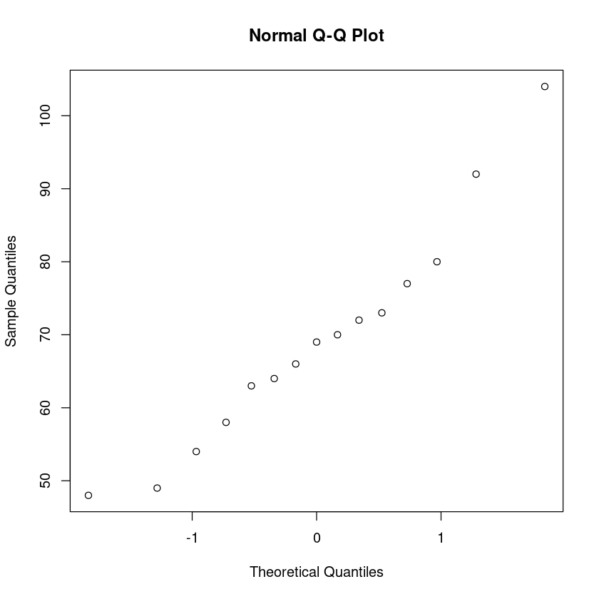

```r
#
x = c(54, 63, 58, 72, 49, 92, 70, 73, 69, 104, 48, 66, 80, 64, 77)

# one sample t confidence interval

#Can we use one sample t confidence interval?
  n = length(x)
  n


#Check the normality using QQ normal plot.
 qqnorm(x)
#Based on the qq normal plot, it seems that the data are from a normal distribution approximately.
```

```r
result = t.test(x, conf.level = 0.99)
result
```

```
	One Sample t-test

data:  x
t = 17.687, df = 14, p-value = 5.652e-11
alternative hypothesis: true mean is not equal to 0
99 percent confidence interval:
 57.60832 80.92502
sample estimates:
mean of x
 69.26667
```

A 99% confidence interval for the population mean is between 57.60832 80.92502. We are 99% sure that the average resting pulse of all members in a health club between 57.60 and 80.93.

### 3.3 Confidence intervals for a population variance

$\sigma^2$: a population variance

A $100(1-\alpha)\%$ confidence interval for $\sigma^2$ is $$ \left( \frac{(n-1)s^2}{\chi^2_{1-\alpha/2,\;n-1}}, \; \frac{(n-1)s^2}{\chi^2_{\alpha/2,\;n-1}} \right). $$

where $s^2$ is the sample variance, and $\chi^2_{\alpha/2,\;n-1}$ is the chisq critical value.

The requirements of the condifidence interval: 1) normality 2) large sample

Drug concentrations were recorded for 25 randomly selected tablets. The scientists want to estimate the **variability** in tablet concentrations. 91.6 92.4 89.7 91.2 83.1 94.5 89.4 89.5 84.0 87.9 89.1 91.7 84.5 89.3 92.7 92.6 84.6 90.5 92.2 90.0 89.2 89.8 92.5 88.7 89.4

Variablity = variance.

The confidence interval is related to $\chi^2_r$, where $r$ is the degrees of freedom.

Construct a 95% confidence interval for the population variance $\sigma^2$.

```r
x= c(91.6, 92.4, 89.7, 91.2, 83.1, 94.5, 89.4, 89.5, 84.0, 87.9, 89.1, 91.7, 84.5, 89.3, 92.7, 92.6, 84.6, 90.5, 92.2, 90.0, 89.2, 89.8, 92.5, 88.7, 89.4)
```

```r
s2 = var(x)
n = length(x)
n

#Lower side critical value
a = 1 - 0.95
q = 1 - a/2

#get the critical value
c1 = qchisq(q,  df=n-1 )
Lower = (n-1)*s2/c1
Lower

#upper side
c2 = qchisq(a/2,  df=n-1 )
Upper = (n-1)*s2/c2
Upper

#A 95% confidence interval for the the population variance is 5.25 and 16.65.
```

25

5.24665165806933

16.6540680806752

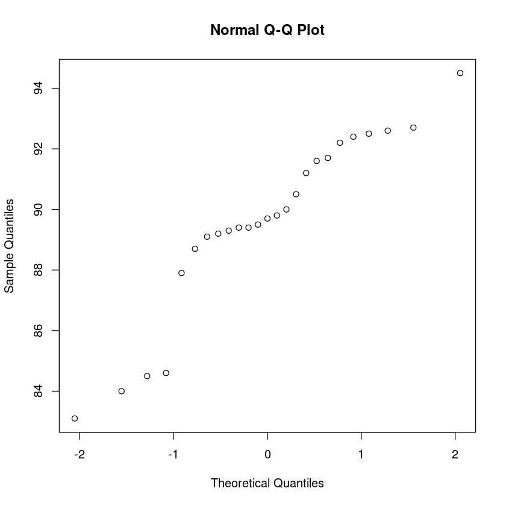

```r
qqnorm(x)
#The data are from a normal distribution approximately.  (or slightly non-normal)
```

### 3.4 Confidence intervals for the occurence rate $\lambda$

For exponential distributions:

Parameters:

- $\lambda$: rate parameter (the same meaning of the parameter in Poisson distributions)
  - Average number of events per unit time
  - Larger $\lambda$ implies shorter expected waiting time

$$ \mathbb{E}[X] = \dfrac{1}{\lambda} $$

Confidence intervals for exponential data or Poisson data.

a $100(1-\alpha)\%$ confidence interval for $\lambda$ is $$ \left( \frac{\chi^2_{2n,\;\alpha/2}}{2S}, \; \frac{\chi^2_{2n,\;1-\alpha/2}}{2S} \right), $$ where $S = \sum_{i=1}^n X_i$.

Example: supposet that the waiting time in faithful data has an exponential distribution with the rate of $\lambda$. Construct a 90% confidence interval for the the rate of occurence.

Waiting time between eruptions and the duration of the eruption for the Old Faithful geyser in Yellowstone National Park, Wyoming, USA.

```r
data(faithful)
head(faithful)
```

A data.frame: 6 × 2

|  | eruptions <dbl> | waiting <dbl> |
| --- | --- | --- |
| 1 | 3.600 | 79 |
| 2 | 1.800 | 54 |
| 3 | 3.333 | 74 |
| 4 | 2.283 | 62 |
| 5 | 4.533 | 85 |
| 6 | 2.883 | 55 |

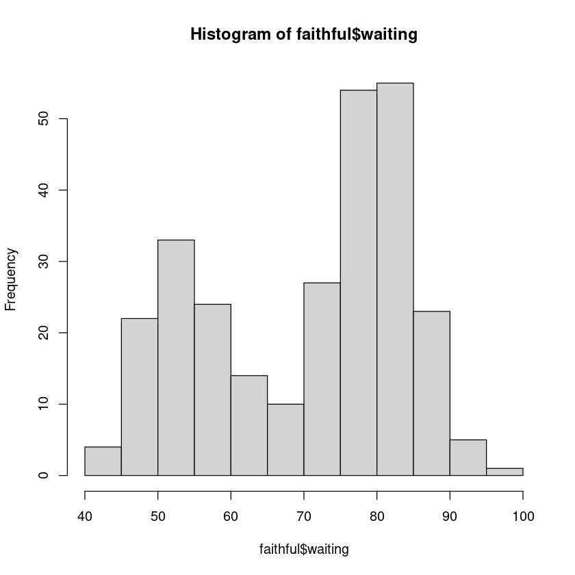

```r
hist(faithful$waiting)

#Clearly it does not follow an exponential distribution

#but if we treat the variable from an exponential distribution
```

```r
#Exact confidence interval for exponential rate lambda

exp.rate.ci <- function(x, clevel = 0.9) {
  n <- length(x)
  S <- sum(x)

  alpha = 1 - clevel

    #based on the formula
  lower <- qchisq(alpha / 2, df = 2 * n) / (2 * S)
  upper <- qchisq(1 - alpha / 2, df = 2 * n) / (2 * S)

  c(lower = lower, upper = upper)
}


#The function to calculation the confidence interval for the rate of occurences.
exp.rate.ci( faithful$waiting, clevel = 0.9  )

#A 90% confidnece interval is between 0.0127 and 0.0155 for the rate of occurences.

#Why we don't one sample t confidence interval?
```

**lower**

0.0127283071228427

**upper**

0.0155405583929259

# Why we don't one sample t confidence interval?

One sample t confidence interval is for a population mean. This problem is not for population mean. It is for the rate of occurence. The goal is different.

1). the data are not from a normal distribution.

2). The parameter of interest is not the population mean.

### 3.5 Bootstrap confidence intervals

Sometimes, the sampling distribution for a statistic can be very complicated. It will be difficult to construct a confidence interval in a parametric way (based on the theoretical distributions)

Bootstrap is computational method, which does not rely on the assumption of the distribution. It is more flexible.

• Advantages: Bootstrapping has required very little in the way of modeling, assumptions, or analysis, and can be applied in an automatic way to any situation, no matter how complicated. An important theme is the substitution of raw computing power for theoretical analysis.

Steps for bootstrap: 1. Sample with replacement from the original sample using the same sample size. 2. Compute the sample statistic. For each bootstrap sample, we can have one statistic ( mean, median, the rate of occurence, ... ) 3. Collect lots of such bootstrap statistics. 4. Use the distribution of bootstrap statistics to assess the sampling variability of the statistic and calculate confidence intervals.

Construct a confidence interval for the population correlation, the standard deviation , the median, IQR, ….

Example: Drug concentrations were recorded for 25 randomly selected tablets. The scientists want to estimate the **variability** in tablet concentrations. 91.6 92.4 89.7 91.2 83.1 94.5 89.4 89.5 84.0 87.9 89.1 91.7 84.5 89.3 92.7 92.6 84.6 90.5 92.2 90.0 89.2 89.8 92.5 88.7 89.4

Variablity = variance.

Construct a 95% confidence interval for the population variance $\sigma^2$, using the boostrap procedure.

**2.5%**

3.606815

**97.5%**

12.8661575

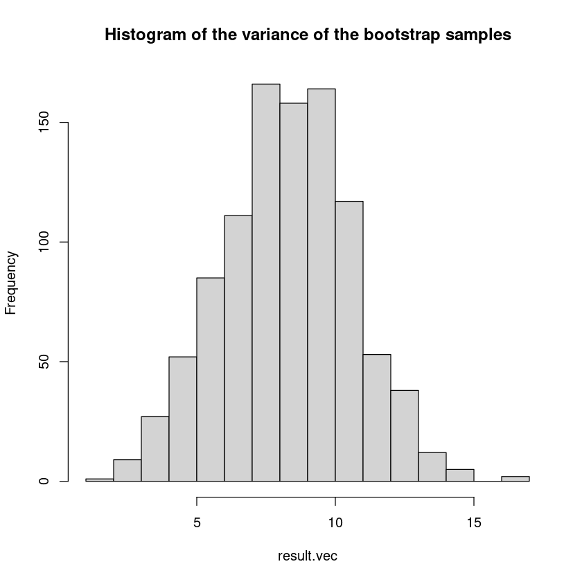

```r
set.seed(191)

c.level = 0.95

x= c(91.6, 92.4, 89.7, 91.2, 83.1, 94.5, 89.4, 89.5, 84.0, 87.9, 89.1, 91.7, 84.5, 89.3, 92.7, 92.6, 84.6, 90.5, 92.2, 90.0, 89.2, 89.8, 92.5, 88.7, 89.4)

n = length(x)


#Define the number of boostrap samples
B= 1000   #500
result.vec = rep(0, B)


for(i in 1:B)
    {
    #For each step,  a bootstrap sample is created.
    #sample with replacement
    xb = sample(x, size = n, replace = TRUE)
    result.vec[i] = var(xb)
}

   hist(result.vec, main = "Histogram of the variance of the bootstrap samples")

  #The lower limit
   ao2 = (1 - c.level)/2   #alpha/2

  quantile(result.vec, prob=c(ao2, 1 - ao2))

# a 95% confidence interval for the popuplation variance is between 3.6 and 12.86.
#5.24665165806933, 16.6540680806752
```

Excersie: Use Car data in canvas. Please construct a 99% confidence interval for the population IQR of the Weight variable. No formula is available, epecially for not a large sample. But we can use bootstrap confidence interval.

```r
set.seed(191)

loc = "car.csv"

c.level = 0.99

dat = read.csv(loc, header = 1)

x = dat$Weight

n = length(x)

n

IQR(x)
```

38

1.2025

**0.5%**

0.50536

**99.5%**

1.64000625

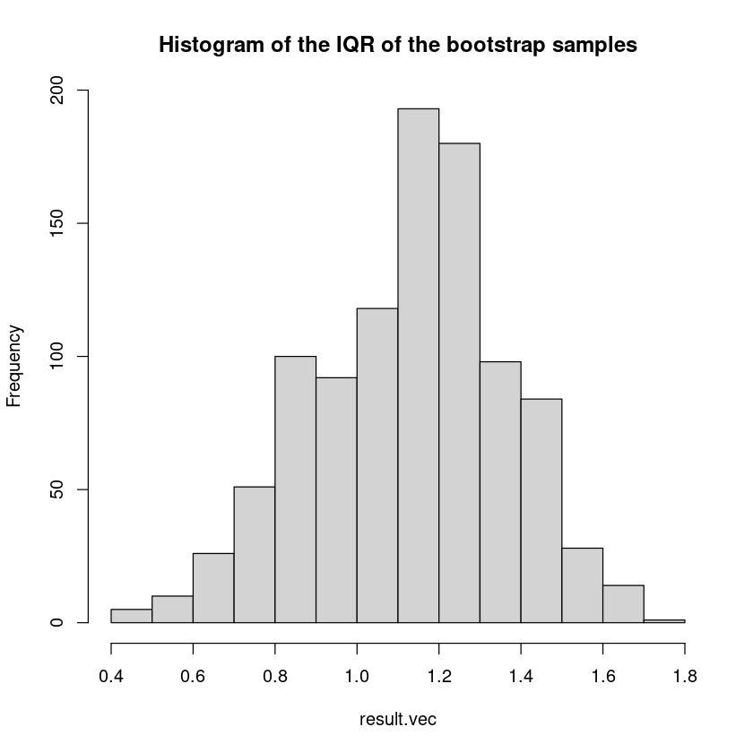

```r
set.seed(367)

#Define the number of boostrap samples
B= 1000   #500
result.vec = rep(0, B)

#Bootstrap sampling, the cauclation of the statistic
for(i in 1:B)
    {
    #For each step,  a bootstrap sample is created.
    #sample with replacement
    xb = sample(x, size = n, replace = TRUE)
    result.vec[i] = IQR(xb)
}

hist(result.vec, main = "Histogram of the IQR of the bootstrap samples")

#The lower limit
ao2 = (1 - c.level)/2   #alpha/2

quantile(result.vec, prob=c(ao2, 1 - ao2))

# a 95% confidence interval for the popuplation IQR is between 0.505 and 1.64
# Theotical confidence interval formula for IQR ,  we don;t know at all.

#R package boot
```

### 3.6 Bayesian credible intervals

In Bayesian inference, an unknown parameter $\theta$ is treated as a **random variable**. We combine:

- a **prior distribution** $p(\theta)$, and
- a **likelihood** $p(y \mid \theta)$,

to obtain the **posterior distribution** via Bayes’ theorem:

$$ p(\theta \mid y) = \frac{p(y \mid \theta)\,p(\theta)}{p(y)}. $$

All Bayesian intervals are derived from this posterior distribution.

Noninformative prior : a flat hirontanal line in an interval.

A $100(1-\alpha)\%$ **Bayesian credible interval** for $\theta$ is an interval $[a,b]$ such that

$$ P(a \le \theta \le b \mid y) = 1 - \alpha. $$

Given the observed data, there is a $1-\alpha$ probability that the true parameter value lies in $[a,b]$.

Key distinction:

- **Bayesian**:

  > “There is a 95% probability that $\theta$ lies in this interval.”
- **Frequentist**:

  > “In repeated sampling, 95% of such intervals would contain the true $\theta$.”

One sample t confidence interval , and some Bayesian credible intervals for a population mean, with informative prior , can be the same.

Example: Use the diamond. a). Construct a 95% confidence interval for the mean weight of all diamonds. b). Construct a 95% Bayesian credible interval for the population mean of weight, using the informative prior.

For both (a) and (b):

$ \bar{X} \pm t_{n-1} s/\sqrt {n} $

```r
loc = "diamond.csv"

dat = read.csv(loc, header = 1)

weight = dat$Weight

#One sample t confidence interval which is also good for Bayesian credible interval with this setting.
t.test(weight, conf.level = 0.95)
```

```
	One Sample t-test

data:  weight
t = 30.157, df = 89, p-value < 2.2e-16
alternative hypothesis: true mean is not equal to 0
95 percent confidence interval:
 0.4806521 0.5484590
sample estimates:
mean of x
0.5145556
```

A 95% confidence interval for the mean weight of all diamonds is between 0.48 and 0.55. We are 95% confidence that the mean weight of all diamonds is between 0.48 and 0.55.

For the Bayesian credible interval,

A 95% Bayesian credible interval for the mean weight of all diamonds is between 0.48 and 0.55. The probability is 0.95 that the mean weight of all diamonds is between 0.48 and 0.55 .

Example: confidence interval for a population proportion , Bayesian credible interval for the probability to claim a loss

We want to derive some confidence intervals for the probability to claim a loss. There were 1047 policies and 159 claims.

95% confidence level

A claim in one policy = "a success"

Probability of a success .

Let use assume that the prior distribuiton for $p$ is beta(1,1).

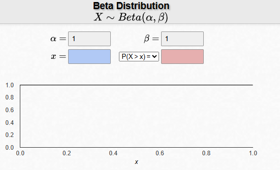

```r
#95% cofidennce interval

prop.test(159, 1047, conf.level = 0.95)

#a 95% confidence interval for the probability to claim a loss in one policy is between 0.1309510 and 0.1753749
```

```
	1-sample proportions test with continuity correction

data:  159 out of 1047, null probability 0.5
X-squared = 506.19, df = 1, p-value < 2.2e-16
alternative hypothesis: true p is not equal to 0.5
95 percent confidence interval:
 0.1309510 0.1753749
sample estimates:
        p
0.1518625
```

Formula for the posterior distribution: $$ \alpha^\ast=\alpha+\sum_{i=1}^n x_i, \qquad \beta^\ast=\beta+n-\sum_{i=1}^n x_i, \qquad B(\alpha^\ast,\beta^\ast)=B\!\left(\alpha+\sum_{i=1}^n x_i,\;\beta+n-\sum_{i=1}^n x_i\right). $$ where $X$ is the number of successes, and ($\alpha$, $\beta$) are the parameter of the prior distribution.

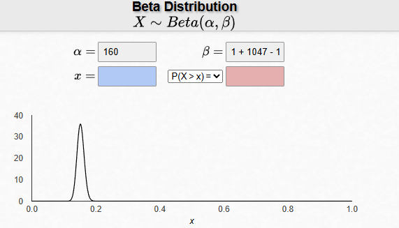

```r
1 + 1047 - 159
```

889

```r
#The posterior distribution is
#beta( 1 + 159,  1 + 1047 - 159 )

#To get 2.5th percentile (lower) and 97.5 th percentile (upper limit)

lower = qbeta(0.025, 160, 889 )
upper = qbeta(0.975, 160, 889 )

#0.975 - 0.025 = 0.95

c(lower, upper)
```

1. 0.131418240006793

2. 0.17488888800793

A 95% bayesian credible interval is between 0.131 and 0.175.

# The posterior distribution is

```r
lower = qbeta(0.025, 161, 890 )
upper = qbeta(0.975,  161, 890 )

c(lower, upper)
```

1. 0.132059155052985

2. 0.175565655274092

```r
bear <- c(
  17.88, 28.92, 33.00, 41.52, 42.12, 45.60, 48.80, 51.84, 51.96, 54.12, 55.56,
  67.80, 68.44, 68.64, 68.88, 84.12, 93.12, 98.64, 105.12, 105.84, 127.92, 128.04, 173.40
)
```

0.0138447462197823

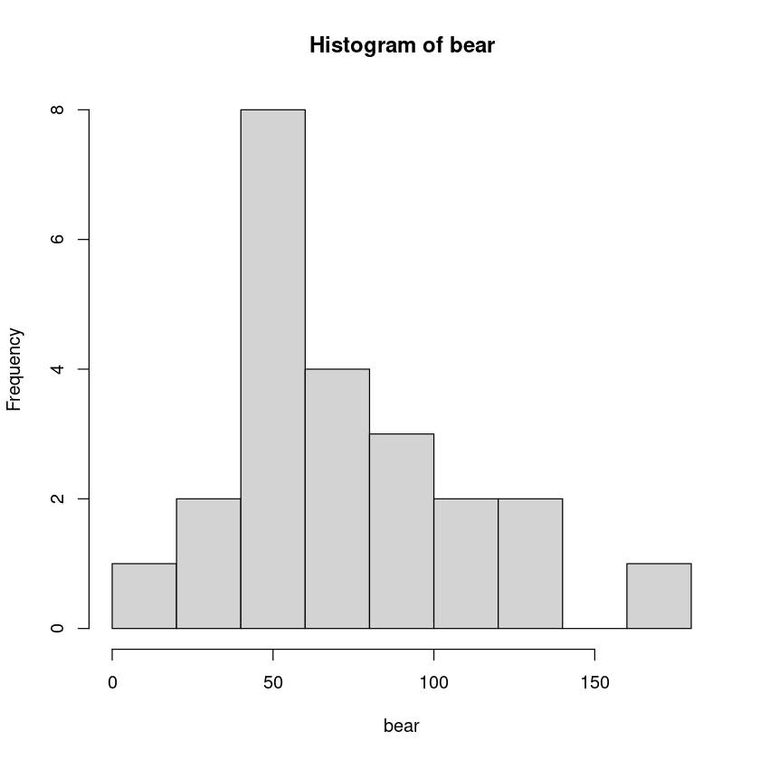

```r
1/mean(bear)

hist(bear, breaks = 6)
```